# Regresión Logistica

Javier Cara

Curso 2018-19

# 1 Data

```r
library(ISLR)
datos = Default
str(datos)
```

```
## 'data.frame':    10000 obs. of  4 variables:
##  $ default: Factor w/ 2 levels "No","Yes": 1 1 1 1 1 1 1 1 1 1 ...
##  $ student: Factor w/ 2 levels "No","Yes": 1 2 1 1 1 2 1 2 1 1 ...
##  $ balance: num  730 817 1074 529 786 ...
##  $ income : num  44362 12106 31767 35704 38463 ...
```

A data frame with 10000 observations on the following 4 variables.

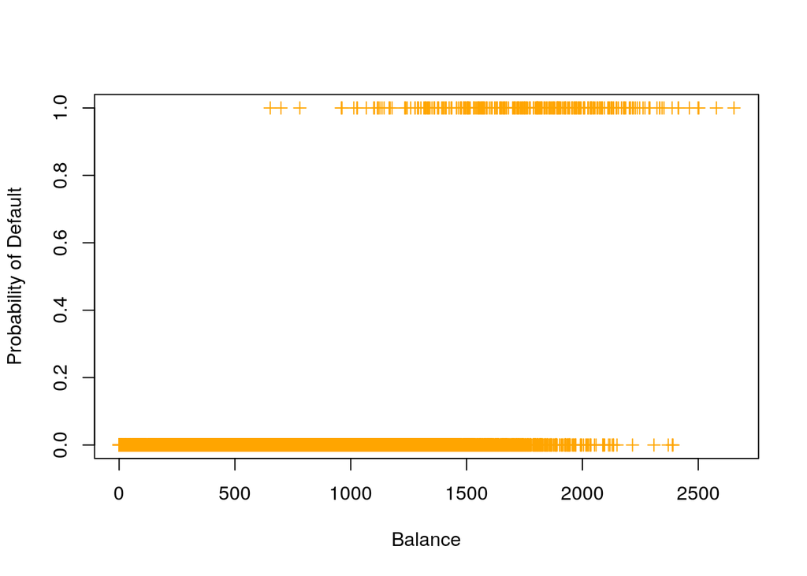

```r
plot(datos$balance, as.numeric(datos$default)-1, pch = 3, col = "orange", xlab = "Balance", ylab = "Probability of Default")
```

# 2 Regresión simple con variable respuesta cualitativa

$$Pr(default|balance_i) = \beta_0 + \beta_1 balance_i + u_i$$

```r
m_rs = lm(default ~ balance, data = datos)
```

Tenemos que convertir *default* a variable numérica:

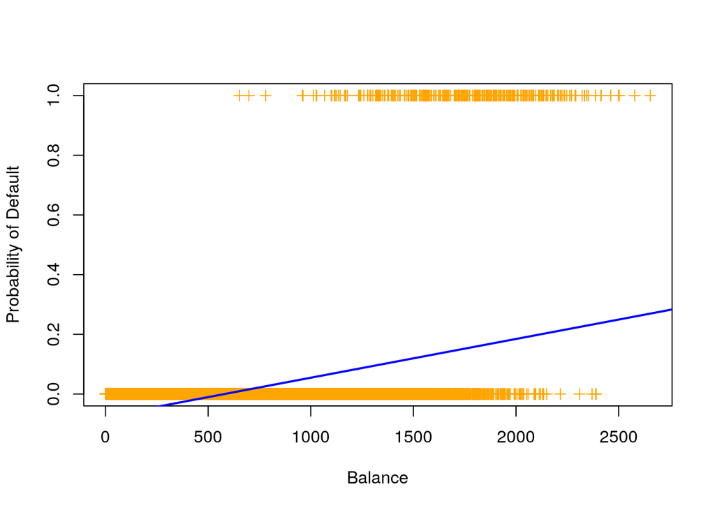

```r
m_rs = lm(as.numeric(default) - 1 ~ balance, data = datos)
plot(datos$balance, as.numeric(datos$default) - 1, pch = 3, col = "orange", xlab = "Balance", ylab = "Probability of Default")
abline(m_rs, col = "blue", lwd = 2)
```

El problema con este modelo es que:

Para evitar estos inconvenientes se utiliza el modelo logístico.

# 3 El modelo logit

Hay muchos modelos que dan valores entre 0 y 1 para todos los valores de x. El que se usa en regresión logística es la denominara función logística:

$$Pr(default|balance_i) = Pr(y=1|x_i) = \frac{e^{\beta_0+\beta_1x_i}}{1+e^{\beta_0+\beta_1x_i}}$$

Suele utilizarse la simplificación $Pr(y=1|x_i) = p(x_i)$. Este modelo puede reescribirse como:

$$\log \left( \frac{p(x_i)}{1-p(x_i)} \right) = \beta_0+\beta_1x_i$$

El término de la izquierda se conoce como *logit*.

# 4 Estimación del modelo

El modelo logit se estima utilizando el *método de máxima verosimilitud*.

```r
m1 = glm(default ~ balance, data = datos, family = binomial)
summary(m1)
```

```
##
## Call:
## glm(formula = default ~ balance, family = binomial, data = datos)
##
## Deviance Residuals:
##     Min       1Q   Median       3Q      Max
## -2.2697  -0.1465  -0.0589  -0.0221   3.7589
##
## Coefficients:
##               Estimate Std. Error z value Pr(>|z|)
## (Intercept) -1.065e+01  3.612e-01  -29.49   <2e-16 ***
## balance      5.499e-03  2.204e-04   24.95   <2e-16 ***
## ---
## Signif. codes:  0 '***' 0.001 '**' 0.01 '*' 0.05 '.' 0.1 ' ' 1
##
## (Dispersion parameter for binomial family taken to be 1)
##
##     Null deviance: 2920.6  on 9999  degrees of freedom
## Residual deviance: 1596.5  on 9998  degrees of freedom
## AIC: 1600.5
##
## Number of Fisher Scoring iterations: 8
```

Los pvalores < 0.05. Por otra parte, $\beta_1 >0$, luego un aumento del *balance* implica un aumento de la *Pr(default)*.

# 5 Predicciones

```r
predict(m1, newdata = data.frame(balance = c(1000, 2000)), type = "response")
```

```
##           1           2
## 0.005752145 0.585769370
```

Lo que obtenemos es Pr(default | xi = 1000) y Pr(default | xi = 2000).

Vamos a dibujar la funcion estimada:

```r
balance_grid = seq(from = min(datos$balance), to = max(datos$balance), by = 1)
pred_grid = predict(m1, newdata = data.frame(balance=balance_grid), type = "response")
```

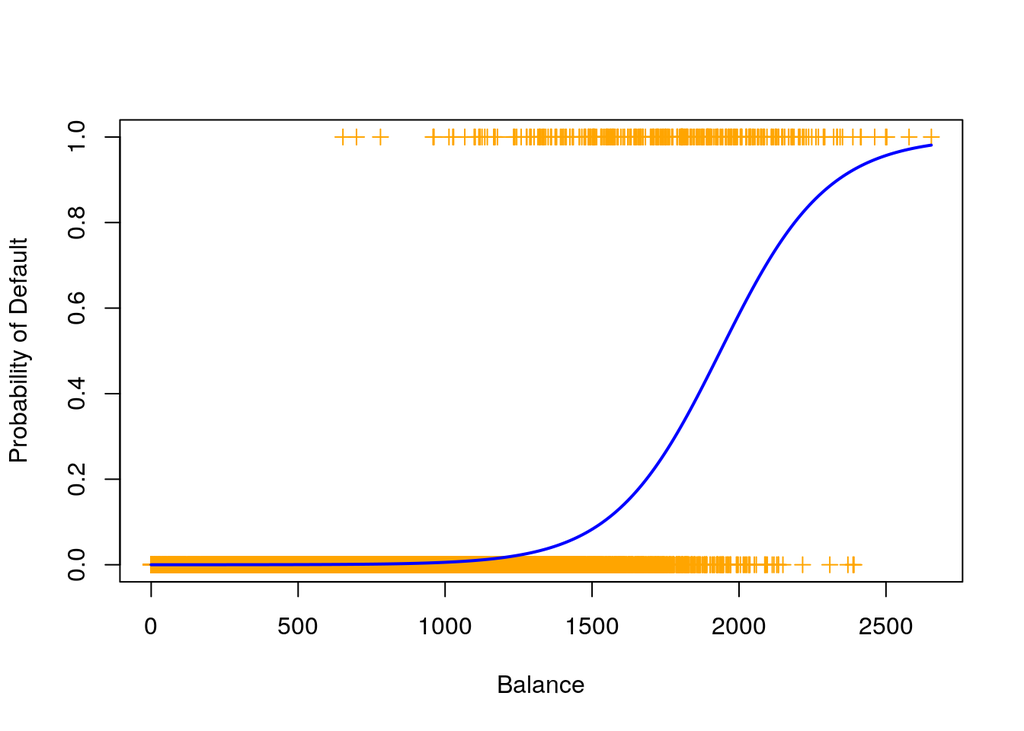

```r
plot(datos$balance, as.numeric(datos$default) - 1, pch = 3, col = "orange", xlab = "Balance", ylab = "Probability of Default")
lines(balance_grid, pred_grid, col = "blue", lwd = 2)
```

Matriz de confusión:

```r
pred1 = predict(m1, newdata = datos, type = "response")
pred2 = rep("No", 10000)
pred2[pred1 > 0.5] = "Yes"
table(datos$default, pred2)
```

```
##      pred2
##         No  Yes
##   No  9625   42
##   Yes  233  100
```

El modelo ha predicho correctamente 9625 + 100 = 9725 de 10000 datos.

## 5.2 Regresores cualitativos.

En este modelo también podemos utilizar regresores cualitativos por medio de variables auxiliares 0 - 1.

```r
m2 = glm(default ~ student, data = datos, family = binomial)
summary(m2)
```

```
##
## Call:
## glm(formula = default ~ student, family = binomial, data = datos)
##
## Deviance Residuals:
##     Min       1Q   Median       3Q      Max
## -0.2970  -0.2970  -0.2434  -0.2434   2.6585
##
## Coefficients:
##             Estimate Std. Error z value Pr(>|z|)
## (Intercept) -3.50413    0.07071  -49.55  < 2e-16 ***
## studentYes   0.40489    0.11502    3.52 0.000431 ***
## ---
## Signif. codes:  0 '***' 0.001 '**' 0.01 '*' 0.05 '.' 0.1 ' ' 1
##
## (Dispersion parameter for binomial family taken to be 1)
##
##     Null deviance: 2920.6  on 9999  degrees of freedom
## Residual deviance: 2908.7  on 9998  degrees of freedom
## AIC: 2912.7
##
## Number of Fisher Scoring iterations: 6
```

Según el pvalor, la condición de estudiante es significativa en la probabilidad de default. Como $\beta_1 >0$, los estudiantes tienen probabilidad de default mayor que los no estudiantes. Se puede comprobar:

```r
predict(m2, newdata = data.frame(student = "Yes"), type = "response")
```

```
##          1
## 0.04313859
```

```r
predict(m2, newdata = data.frame(student = "No"), type = "response")
```

```
##          1
## 0.02919501
```

# 6 Regresión logística múltiple

Los datos son ahora: $y_i, x_{1i}, x_{2i}, \ldots, x_{pi}, \ i = 1, \ldots, n$. El modelo logit se generaliza como:

$$Pr(y=1|X_i) = p(X_i) = \frac{e^{\beta_0 + \beta_1 x_{1i} + \beta_2 x_{2i} + \cdots + \beta_1 x_{pi}} }{1 + e^{\beta_0 + \beta_1 x_{1i} + \beta_2 x_{2i} + \cdots + \beta_1 x_{pi}} }$$

O también:

$$\log \left( \frac{p(X_i)}{1-p(X_i)} \right) = \beta_0 + \beta_1 x_{1i} + \beta_2 x_{2i} + \cdots + \beta_1 x_{pi}$$

donde $X_i = \{x_{1i}, x_{2i}, \cdots, x_{pi}\}$.

```r
m3 = glm(default ~ balance + income + student, data = datos, family = binomial)
summary(m3)
```

```
##
## Call:
## glm(formula = default ~ balance + income + student, family = binomial,
##     data = datos)
##
## Deviance Residuals:
##     Min       1Q   Median       3Q      Max
## -2.4691  -0.1418  -0.0557  -0.0203   3.7383
##
## Coefficients:
##               Estimate Std. Error z value Pr(>|z|)
## (Intercept) -1.087e+01  4.923e-01 -22.080  < 2e-16 ***
## balance      5.737e-03  2.319e-04  24.738  < 2e-16 ***
## income       3.033e-06  8.203e-06   0.370  0.71152
## studentYes  -6.468e-01  2.363e-01  -2.738  0.00619 **
## ---
## Signif. codes:  0 '***' 0.001 '**' 0.01 '*' 0.05 '.' 0.1 ' ' 1
##
## (Dispersion parameter for binomial family taken to be 1)
##
##     Null deviance: 2920.6  on 9999  degrees of freedom
## Residual deviance: 1571.5  on 9996  degrees of freedom
## AIC: 1579.5
##
## Number of Fisher Scoring iterations: 8
```

Se observa lo siguiente:

- balance y student son significativas, income no lo es.
- $\beta_1 >0$, luego un aumento del balance (manteniendo fijos income y student) implica un aumento de la Pr(default).
- $\beta_3 <0$, luego los estudiantes (manteniendo fijos income y balance) tienen menor Pr(default) que los no estudiantes. Esto entra en contradicción con lo observado cuando se analizaron los datos de student de forma aislada. Pero:
  - Si los datos de balance no son disponibles, un estudiante tiene más probabilidad de default que un no estudiante.
  - Si los datos de balance están disponibles, para un mismo nivel de balance, los no estudiantes tienen mayor probabilidad de default que los estudiantes.

```r
predict(m3, newdata = data.frame(balance = 1500, income = mean(datos$income), student = "Yes"), type = "response")
```

```
##          1
## 0.05681881
```

```r
predict(m3, newdata = data.frame(balance = 1500, income = mean(datos$income), student = "No"), type = "response")
```

```
##         1
## 0.1031582
```

# 7 Validation set approach

- Creamos los datos para el train y el test:

```r
set.seed(1)

n = nrow(datos)
n_train = round(n/2)
n_test = n - n_train

v = 1:n
pos_train = sample(v, n_train, replace = F) # muestreo sin reemplazamiento
pos_test = v[-pos_train]

# dividimos los datos en training set y validation set
datos_train = datos[pos_train,]
datos_test = datos[pos_test,]
```

- En el training set estimamos el modelo:

```r
mtr = glm(default ~ balance + income + student, data = datos_train, family = binomial)

# error en el training set
y_train = datos_train$default
y_train_p = predict(mtr, datos_train, type = "response")
y_train_p1 = rep("No", n_train)
y_train_p1[y_train_p > 0.5] = "Yes"
(M_train = table(y_train, y_train_p1))
```

```
##        y_train_p1
## y_train   No  Yes
##     No  4816   18
##     Yes  106   60
```

Error cometido

```r
(n_train - sum(diag(M_train)))/n_train*100
```

```
## [1] 2.48
```

- En el test set calculamos el error de predicción:

```r
y_test = datos_test$default
y_test_p = predict(mtr, datos_test, type = "response")
y_test_p1 = rep("No", n_test)
y_test_p1[y_test_p > 0.5] = "Yes"
(M_test = table(y_test, y_test_p1))
```

```
##       y_test_p1
## y_test   No  Yes
##    No  4803   30
##    Yes  114   53
```

Error cometido

```r
(n_test - sum(diag(M_test)))/n_test*100
```

```
## [1] 2.88
```